# Data Science Project

Liza Pikovsky, Matanel Zoldan, Osnat Versulker, Shaul Ora, Netanel Malka

24 6 2020

The education system in Israel is divided into several types that combine online learning tools. When, On the one hand, schools that encourage activity in computerized systems to enter grades and monitor students. And on the other hand, low-awareness schools use these systems, preferring manual monitoring by teachers. As part of our undergraduate studies in industrial engineering and management, we conduct research. The aim of the study is to understand the difficulties that teaching staff face and how much change and accessibility is needed in the computerized systems in the education systems.

## Statistic analysis

Median year of birth of the person who answered the survey

```
## [1] 1975
```

Average weekly hours

```
## [1] 20.62264
```

Standard deviation of learning from shopping

```
## [1] 7.825224
```

## The Cochran-Armitage Trend Test

The Kokran-Armitage test is a variation of a live-squared test that is suitable for assessing the trend of the relationship between two qualitative variables, one of which is measured on a arranged scale of measurement, and the other receives only two values. Unlike a quadratic live test, this test takes into account the fact that there is an order between the values of the ordered variable. This test is a particular case of the M square test.

```
##
##  The Cochran-Armitage Trend Test
##
## data:  The type of data is variable!
## Z = 0.961, p-value = 0.3368
```

## 1. Distribution of answers by region

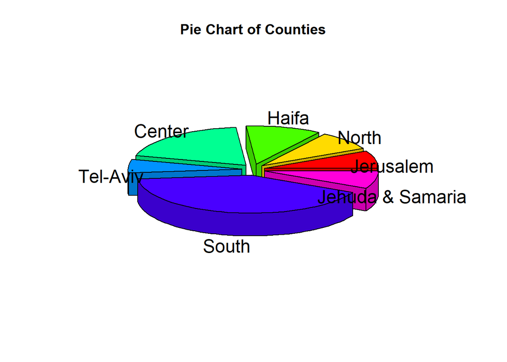

## 2. Age distribution of the respondents

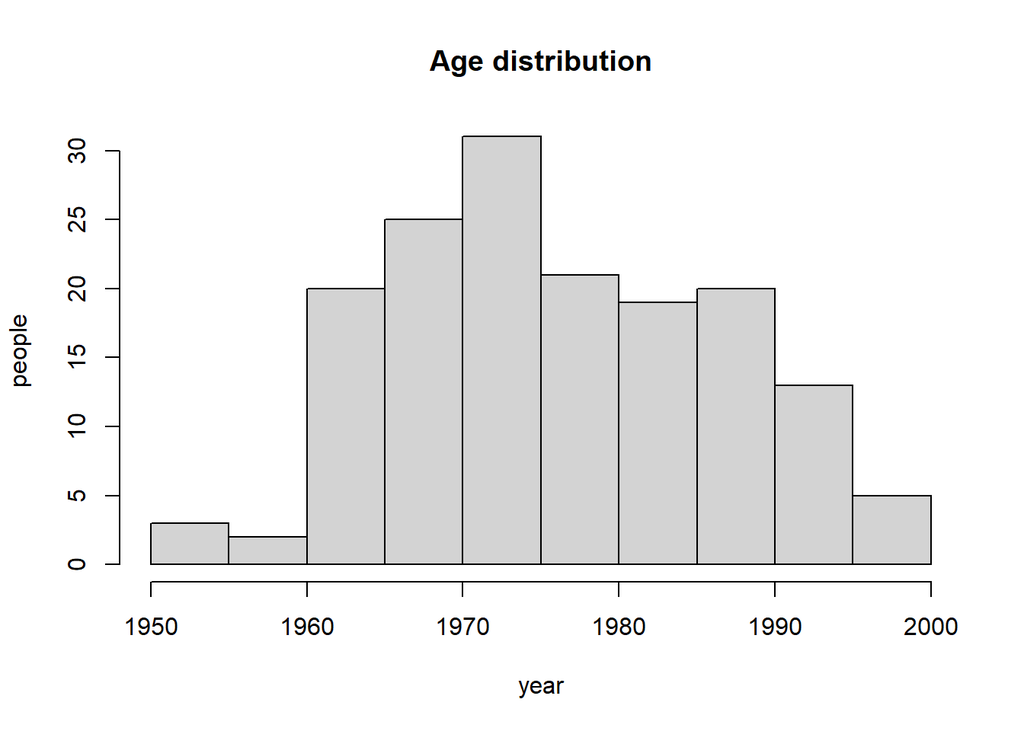

## 3. Seniority vs technological capabilities

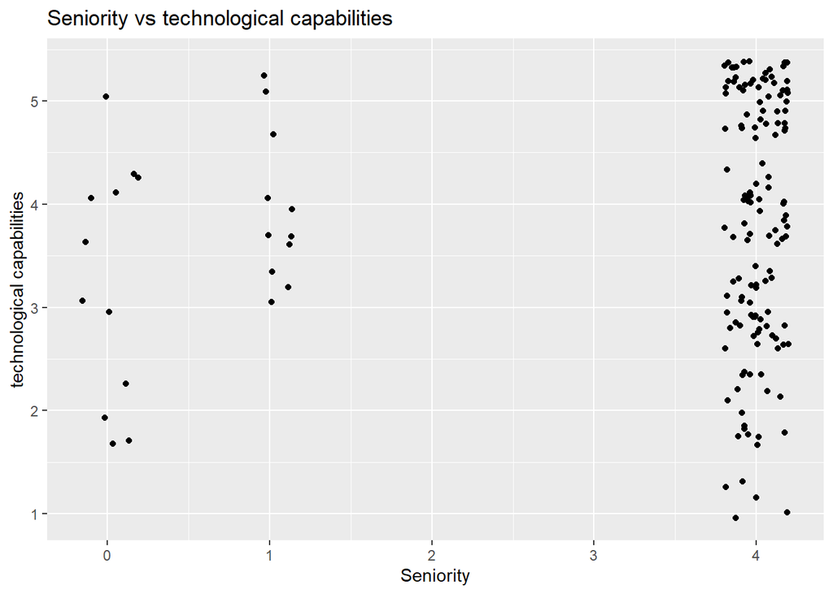

## 4. Educational institution sector

מקראexplanation: 0 = state 1 = State religious 2 = Haredi ניתן לראות כי חלק ניכר ממשתתפי הסקר הם מורים בבי"ס ממלכתיים

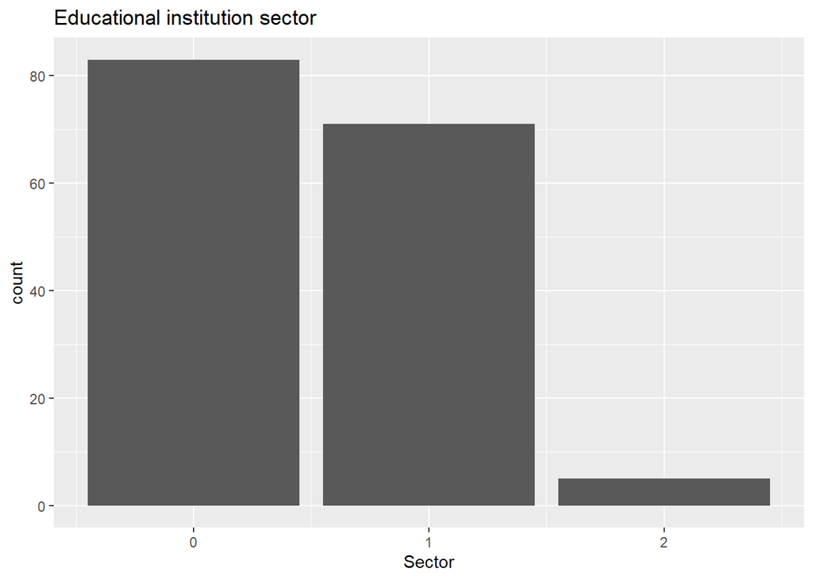

## 5. Number of hours distributed over the number of classes

It can be seen that as the number of classes a teacher teaches in them increases the distribution of hours he will teach decreases.

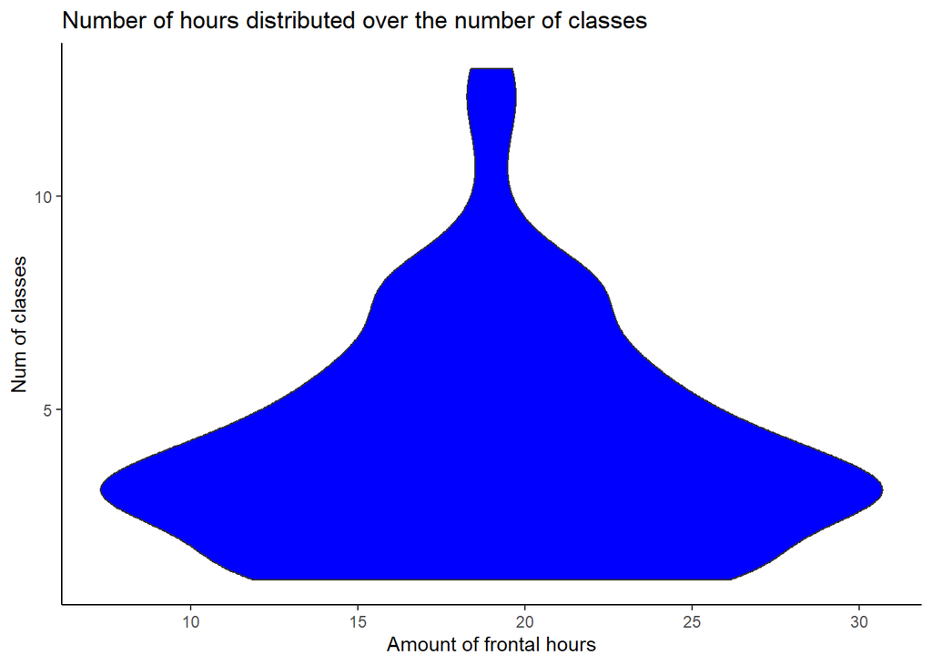

## 6. Effect of study seniority on the number of frontal hours

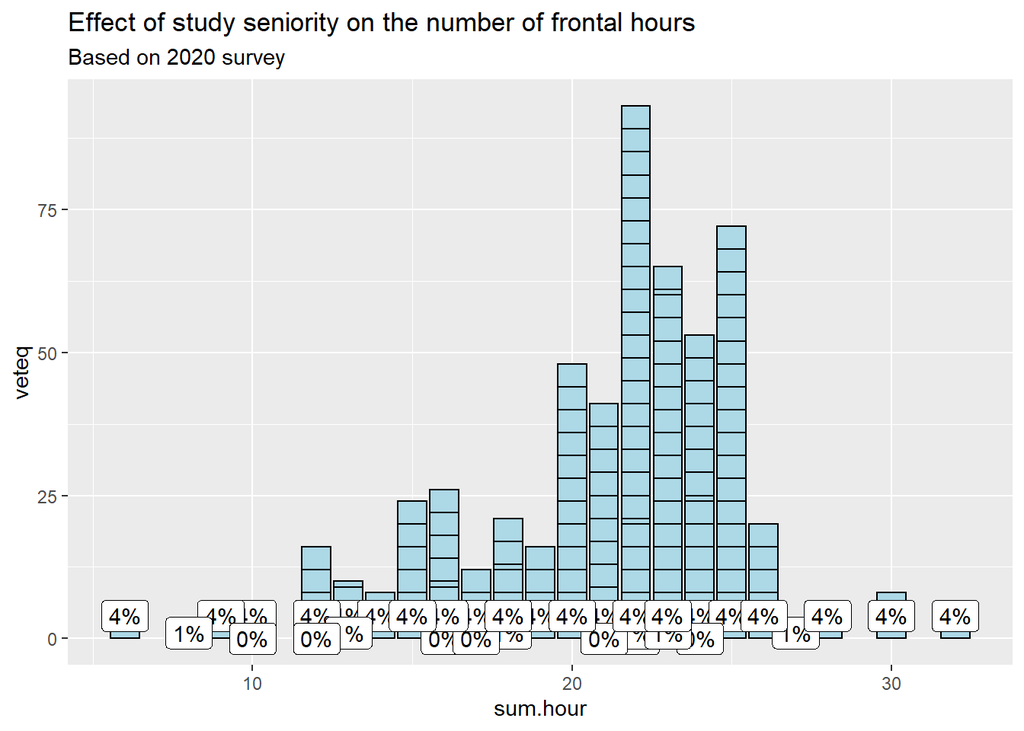

## 7. Distribution by gender

1 = Female 0 = Male

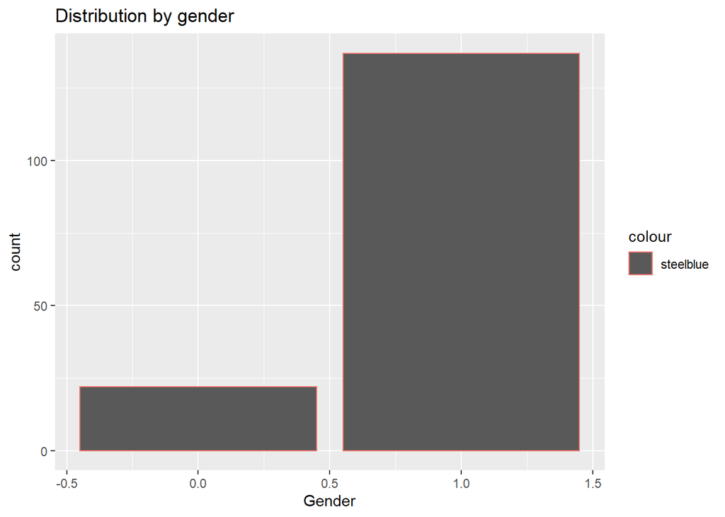

## 8. Has online learning strengthened the control of online teaching?

It can be seen from the graph that distance learning has strengthened mastery of online teaching and in the future they want to continue.

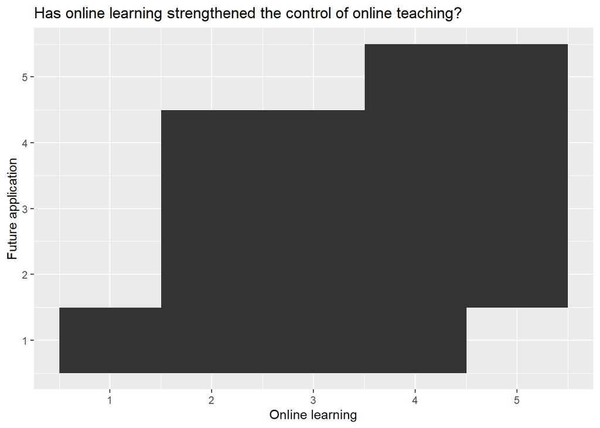

## 9. Using Online Courses - Universities vs. Colleges

1 = Colleges 2 = Universities

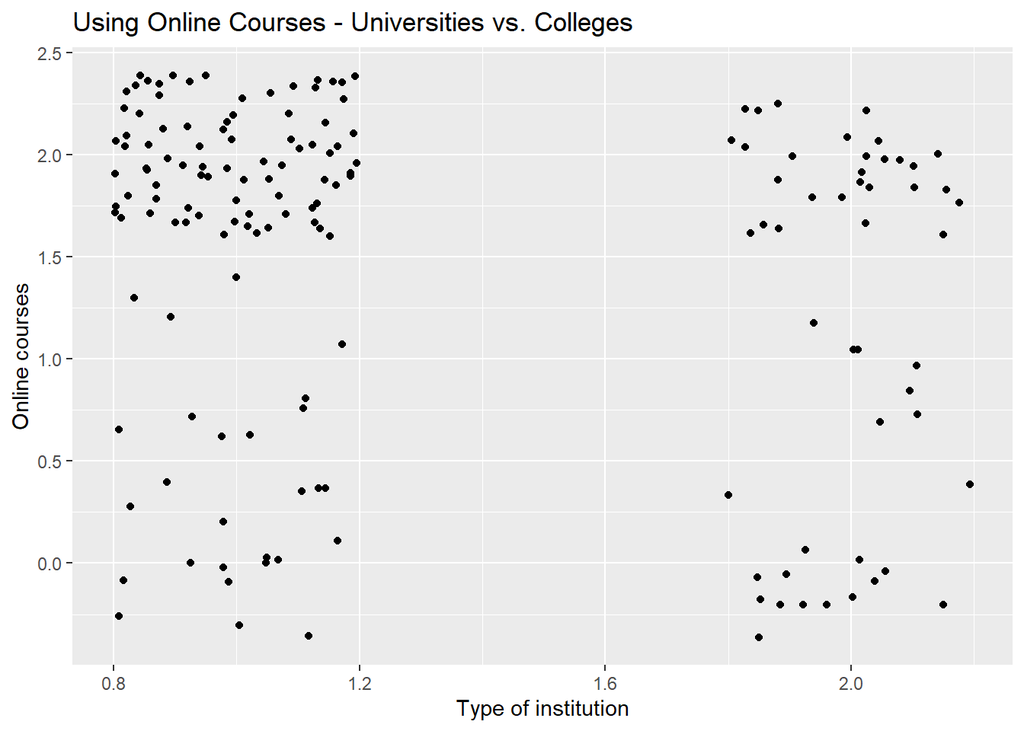

## 10. Study hours online during the Corona

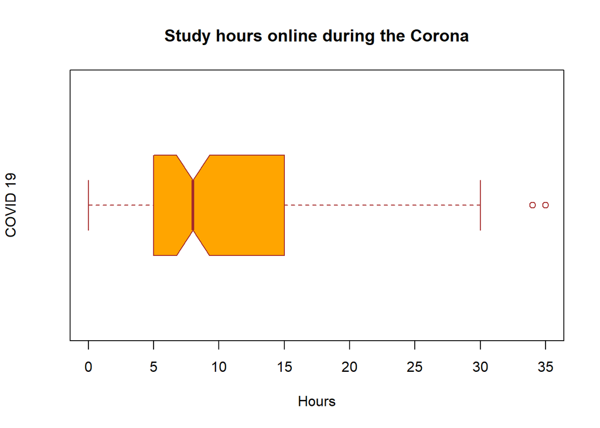

## Relationship between routine study hours and the corona period QQPLOT graph that analyzes the relationship between frontal study hours and online study hours It can be seen that there is a gap between the normal hours and the corona hours.

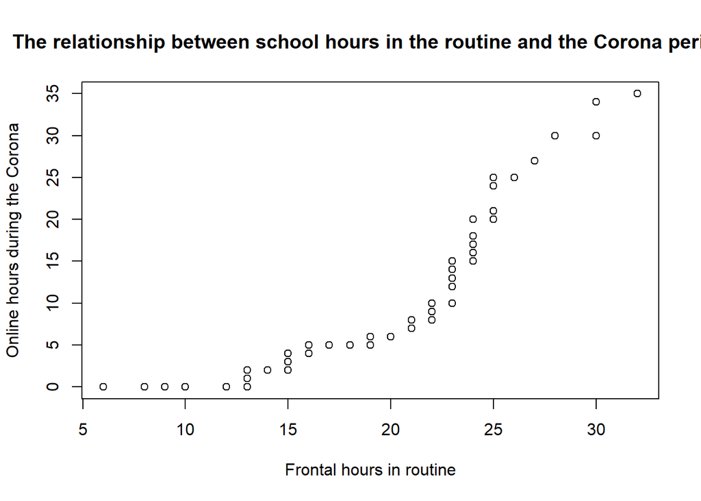